# DATA Assessment 2024-25

## Department of Computer Science, University of York

### DATA: Introduction to Data Science

## Task 1: Domain Analysis (5 marks)

Given the business domain and the data overview presented (in the assessment paper), provide a brief description of

- the business problem and its significance to the relevant sector;
- the link between the business problem and the field of data science;
- the main areas of investigation; and
- potential ideas and solutions.

**Word Limit:** 300 words

**Answer:**

The NHS holds huge amounts of data related to patients, healthcare professionals, and healthcare facilities. However the problem arises when this data resides across multiple files making it difficult to efficiently retrieve, analyse and draw insights efficiently. Addressing this problem would significantly improve healthcare delivery, optimise resource allocation, and enhance patient outcomes, which are key priorities in the healthcare sector.

Data science provides the tools to address this problem by transforming raw, unstructured data into actionable insights. Techniques such as data processing, data exploration, and predictive analytics using machine learning can help support the NHS at achieving a more efficient, effective, and patient-centred healthcare system, with data-informed decisions.

My project will focus on 3 main areas, aimed at supporting hospital administrators, policymakers and medical professionals. First, I will explore patterns in patient readmissions, which may indicate incomplete or ineffective care. These insights can help hospital administrators improve care pathways and optimise resource planning. Second, I will compare patient outcomes between NHS and private hospitals, offering insights to policymakers to evaluate NHS hospital quality and allocate resources effectively. Third, I aim to identify high-risk patients to support medical professionals to intervene earlier, potentially reducing complications and improving patient outcomes.

To address these areas, I will first build an efficient database that reduces data redundancy and improves query performance. I propose developing a predictive model for patient readmission using medical history and visit patterns, and design a clustering model to segment patients by risk levels, allowing NHS staff to prioritise care more effectively. I also aim at using inferential statistics to compare one aspect of patient outcomes, surgery success rates, between NHS hospital and private hospital type.

## Task 2: Database Design (30 marks)

(**10 marks**) Design a conceptual database schema for the given NHS context, represented as an entity-relationship (ER) diagram using Chen's notation (as taught in the module). Your ER diagram should capture all the essential entities, attributes, primary keys, relationships, and cardinalities, necessary to model the healthcare operations described in the scenario.

The healthcare data currently exists in the form of six csv files called *Appointments_Data.csv, Prescription_Billing_Insurance_Data.csv, Service_Billing_Insurance_Data.csv, Medical_Appointments_Data.csv, Medical_Surgeries_Data.csv and Medical_Tests_Data.csv*, provided on VLE (*path given in page 6 in the assessment paper*). These files have all the existing records. The tables available in the csv files are unnormalised. The information about the different columns in them is given in Tables 1-6 (in the paper), respectively.

(**10 marks**) Normalise the provided tables to the Third Normal Form (3NF), minimising data redundancy and ensuring data integrity. Demonstrate the steps involved in achieving 3NF, showing how you decomposed the tables through 1NF and 2NF.

(**10 marks**) Finally, implement your 3NF schema in an SQLite database using SQL. Your answer should include the SQL statements needed to accomplish this step and populate the final tables with the appropriate data.

Your submission should include the final SQLite database file.

Your answer should clearly cover the following:

- Any assumptions you are making about the given scenario;
- The designated primary and foreign keys, existing relationships, and identified functional dependencies;
- The steps followed and justifications for the decisions made.

**World Limit**: 500 words. This limit applies only to the explanations. There is no limit on any associated code/SQL statements or figures.

**Answers:**

**Part a: ER Diagram**

[figure not shown]

**Part b: Normalising tables**

**1) Normalising Appointments_data table**

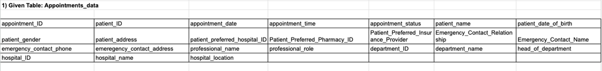

Primary key: Composite primary key = {appointment_ID, patient_ID, emergency_contact_address, department_ID, hospital_ID, {professional_role, professional_name, department_ID}}

**1NF:**

- Rule: All attributes must be atomic
- Given table in Appointment_data.csv has all atomic values, so it's already in 1NF.

**2NF:**

Functional dependencies:

- FD1: appointment_ID -> (functionally determines) -> {patient_ID, appointment_data, appointment_time, appointment_status, proffesional_name, proffesional_role, department_ID}
- FD2: patient_ID -> (functionally determines) -> {patient_name, patient_date_of_birth, patient_gender, patient_address, patient_preffered_hospital_ID, patient_preffered_pharmacy_ID, patient_preffered_insurance_provider}
- FD3: emergency_contact_phone -> (functionally determines) -> {emergency_contact_relationship, emergency_contact_name, emergency_contact_phone, emergency_contact_address}
- FD4: hospital_ID -> (functionally determines) -> {hospital_name, hospital_location}
- FD5: department_ID -> (functionally determines) -> {hospital_ID, department_name, head_of_department}

To be in 2NF, every non-primary key column should be fully functionally dependent upon all the columns that make up the primary key. So, every non-primary key columns must not have any partial functional dependency. From FD 1 - 5, we can see that there are several non primary key attributes dependent on a proper subset of the primary key (partial dependecy). So, the table is not in 2NF.

The corresponding 2NF consists of the following 6 tables:

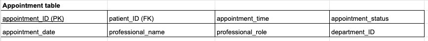

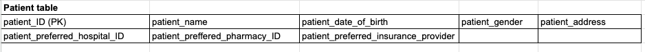

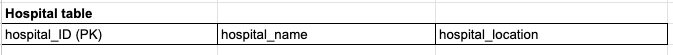

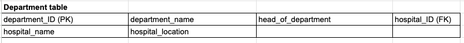

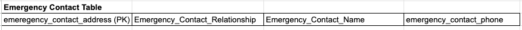

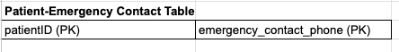

**3NF:**

In order to be in 3NF, non non prime attribute should be transitiviely dependent on the primary key. From the 2NF tables, there exists transitive dependencies in the following tables:

Department table:

- department_ID -> hospital_ID -> hospital_name, hospital_location

Appointment table:

- appointment_ID -> professional_name -> professional_role

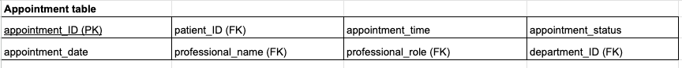

Foreign keys= {professional_name, professional_role and department_ID} references the Professional table.

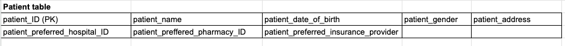

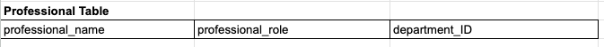

Since professional_ID is not present in the CSV file we can make the composite keys= {professional_name, professional_role and department_ID} as the primary key, assuming that this combination is unique.

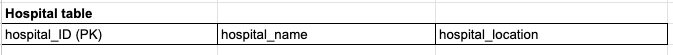

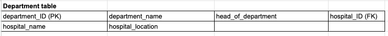

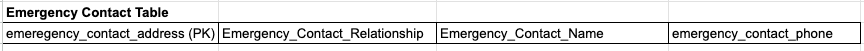

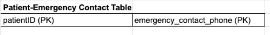

**2) Normalising the Prescription_Billing_Insurance_Data table**

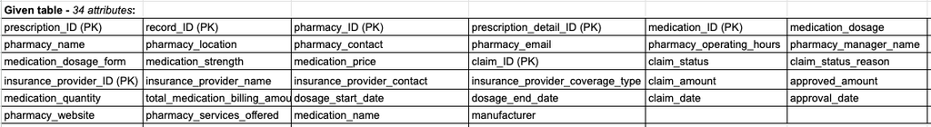

Primary key = Composite keys = {prescription_ID, record_ID, pharmacy_ID, prescription_detail_ID, medication_ID, claim_ID, insurance_provider_ID}

**1NF:** Given table is already in 1NF.

**2NF:**

Functional dependencies:

- FD1: prescription_ID -> (functionally determines) -> {record_ID, pharmacy_ID, pharmacy_name, pharmacy_location, pharmacy_contact, pharmacy_email, pharmacy_operating_hours, pharmacy_manager_name, pharmacy_website, pharmacy_services_offered, patient_ID, professional_role, professional_name, department_ID}
- FD2: pharmacy_ID -> (functionally determines) -> {pharmacy_name, pharmacy_location, pharmacy_contact, pharmacy_email, pharmacy_operating_hours, pharmacy_manager_name, pharmacy_website, pharmacy_services_offered
- FD3: medication_ID -> (functionally determines) -> {medication_name, manufacturer, medication_dosage_form, medication_strength, medication_price}
- FD4: insurance_provider_ID -> (functionally determines) -> {insurance_provider_name, insurance_provider_contact, insurance_provider_coverage_type}
- FD5: claim_ID -> (functionally determines) -> {claim status, claim_status_reason, claim_amount, approved_amount, claim_date, approved_date, insurance_provider_ID, insurance_provider_name, insurance_provider_contact, insurance_provider_coverage_type, prescription_detail_ID}
- FD6: prescription_detail_ID -> (functionally determines) -> {medication_dosage, medication_quantity, total_medication_billing_amount, dosage_start_date, dosage_end_date, prescription_ID, medication_ID, claim_ID}

Based on the 2NF requirements previously stated, from FD 1-6, we can see that there are several non primary key attributes dependent on a proper subset of the primary key. So, the table is not in 2NF.

The following 6 tables are in 2NF:

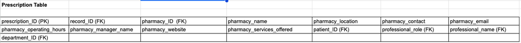

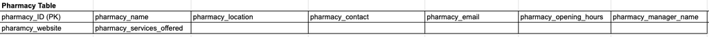

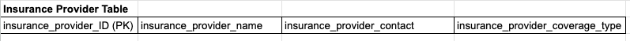

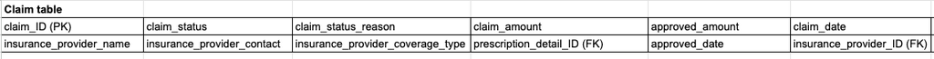

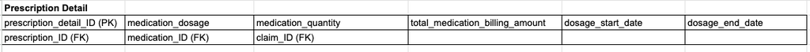

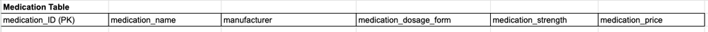

**3NF:**

In the 2NF tables, there exists transitive dependencies in the following tables:

- Prescription table:

prescription_ID -> pharmacy_ID -> pharmacy_name, pharmacy_location, pharmacy_contact, pharmacy_email, pharmacy_operating_hours, pharmacy_manager_name, pharmacy_website, pharmacy_services_offered

- Claim table:

claim_ID -> insurance_provider_ID -> insurance_provider_name, insurance_provider_contact, insurance_provider_coverage_type

The following are the final 3NF tables:

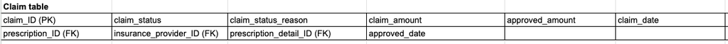

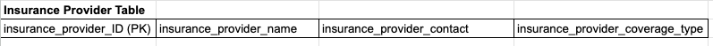

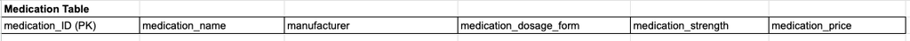

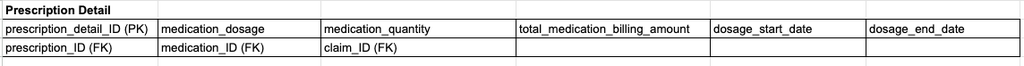

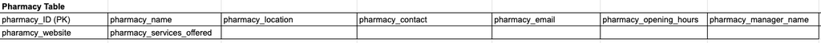

[figure not shown]

**3)Normalising Service_Billing_Insurance_Data table**

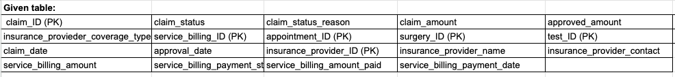

**1NF:** Given table is already in 1NF.

**2NF:**

Functional dependencies:

- FD1: claim_ID -> (functionally determines) -> claim_status, claim_status_reason, claim_amount, approved_amount, claim_date, approval_date, insurance_provider_ID, insurance_provider_name, insurance_provider_contact, insurance_provider_coverage_type, service_billing_ID, service_billing_amount, service_billing_payment_status, service_billing_amount_paid, service_billing_payment_date
- FD2: insurance_provider_ID -> (functionally determines) -> insurance_provider_name, insurance_provider_contact, insurance_provider_coverage_type
- FD3: service_billing ID -> (functionally determines) -> service_billing_amount, service_billing_payment_status, service_billing_amount_paid, service_billing_payment_date, appointment_ID (nullable FK), surgery_ID (nullable FK), test_ID (nullable FK)